# 2 コミュニケーションについて再考する：変容する世界における研究

本章では、OSの核となる動機および構成要素について論じる。まずは現代の研究に影響を及ぼす諸問題を整理のうえ、そうした問題に対処する手段としてOS運動が出現したことについて述べる。最後にOSの環境を支える価値観の分析をおこない、諸々の資源や考えを共有する自由としてオープン性を解釈することがもたらす重要な点を浮き彫りにする。

## 2.1 研究が抱える諸課題：「閉じられた」科学の支配

研究におけるオープン性に関する議論の出発点は、何が「閉ざされた（閉鎖的な）」ものと認識されているのか、なぜそうなのかということを問うことである。たしかに、OS運動を整理するひとつの仕方は、現在の科学コミュニケーション、特にますます競争的になり、商業化され、自己参照的なものになっている研究公表の文化に対する反動としてとらえるものだ。この50年間で研究活動の規模と国際的な広がりは爆発的に拡大し、専門的な科学者として訓練を受ける人の数も世界中で増えている。それに伴い研究の成果物は指数関数的に増大し、ますます専門化され、諸々の発見を普及・評価する既存のシステムは圧迫されつつある。出版サービスは技術的・管理的に洗練され、読者を情報洪水から救い出せるように膨大な数の専門ジャーナルと索引ツールからなるエコシステムが醸成されてきた。研究者は著者・査読者・編集者として無償の労働力を提供してきた一方、出版に対する財政的支援はこれまで以上に高くなった購読料に対応せざるをえず、最終的に、裕福な研究機関以外にとっては学術ジャーナルへのアクセスが手の届かないものになってしまった。同時に職や助成金の獲得をめぐる激しい競争は申請者数の増加と成功率の減少を伴い、誰が優れた研究をおこない雇用と資金に値するものであるかを判断するために用いられる評価システムに圧力をかけている。多くの国や研究機関では生産された論文の量や論文が掲載された学術ジャーナルの名声が研究の質や信頼性を端的に示す尺度となっている。

この状況を例示することとして、各ジャーナルに掲載された論文が一定期間に何回引用されたかを数値化するインパクトファクターがよく使われていることがあげられる。もともとインパクトファクターはひとりの著者や複数からなる共著者らの質ではなく学術ジャーナルの質を測るためのものであったが、研究領域における個々の著者の影響力を測るために広く採用されるようになった。この指標を用いることで出版社が築き上げた研究のコミュニケーションおよび評価の牙城が強化された。世界中のほとんどの科学評価システムにおいて、インパクトファクターの高い学術ジャーナルに掲載された論文だけが唯一の研究成果物として扱われ続けている。データ・モデル・ソフトウェア・機器など、論文を執筆するための単なる手段とみなされるその他のコンポーネントについてはほとんど考慮されることがない[^1]。こうして知識を追い求めることは、モジュール式の積み木のように、本文を執筆する土台となるようなオブジェクトおよび手順の秩序だった集積体として想像されるようになり、知識そのものは公的資金や官民連携によってその生産に助成金が出されることも多いが、購読料を支払う余裕のある人たちだけが利用できる論文という体裁の単位（いささか皮肉にも「公表可能な最小限のもの」と呼ばれる）でコモディティ化されるようになった[^2]。このことが出版社に高い利益をもたらしているとともに、科学的知識のふさわしいあり方や科学的知識の対象となりうる人々の範囲を著しく制限してしまっている。そしてこれは実際に出版がなされたケースに限っての話である。膨大な数の科学的成果はそれを生み出した機関の外部に公表されることはないのだから。それには軍事資金や産業資金により実施される科学の大部分が含まれ、時に秘密主義的であるため、ある時点でどのようなトピックが研究されているのか（ましてや、どこで誰がどのような結果を出しているのか）ということさえ知られていない。また個人データ保護や研究結果がはらむ潜在的な影響に対する懸念など、さまざまな理由で成果物が非公開とされる機密性の高い主題に関する公的資金による研究も含まれるだろう。

科学コミュニケーションの商業化とジャーナル出版でのその具現化は深刻な認識論的問題をもたらしている（Radder 2010, 2019）。このシステムでは出版物の一部として提示されるもの以外の研究コンポーネントについて、その責任ある普及および精査に対するインセンティブや報酬が提供されない。ほとんどの研究データやモデル・手順はそれらを生成した研究者の集団を超えて流通することはない。たとえそれらが（たとえばデータベース上で、あるいは研究論文の補足情報として）公表されたとしても、そうしたコンポーネントを精査目的で利用できるようにすることに費やされたた多大な労力を評価する仕組みはないといってよい。論文を大量に発表することに重点がおかれているため、研究者はできるだけ早く結果を発表することが求められるが、そのことと徹底的な手順でチェックすること、実験を再現すること、さまざまな手法で結果を検証すること、より広く普及させるためにデータを整形すること、研究デザインの改善や成果物の文脈づけに役立つ可能性のある他領域の関連専門家へ相談することを組み合わせるのには困難を伴う（Edwards and Roy 2017）。さらに資金獲得という圧力が研究者らに自身の研究の可能性を誇張させてしまいかねないのと同様に、権威あるジャーナルに掲載されることへのプレッシャーも結果を誇張し、および／ないし、過度に一般化する傾向をもたらしており、それゆえ、推論の範囲や妥当性について必ずしも十分に正当化されない仮定がなされることになってしまう。このような問題はpハッキングや出版バイアスなどの統計的不正行為を含め、査読の過程で特定され対処されることが期待されるだろう。しかし査読は出版において中心的な役割を担っているにもかかわらず、それ自体が目に見える活動ではなく報酬のある活動でもないため、この骨の折れる作業のボランティアを見つけることや査読が本来あるべき徹底したものであることを保証するのも難しい（Heesen and Bright 2019）。また査読者向けの正式なトレーニングがあるわけではなく、キャリアの浅い研究者は通常、出版活動の現場で示されるわずかな指針や、査読者のコメントを受ける側としての自身の特異な経験、上級の学術メンターからの同じく特異な助言以外には何の準備もなしにその役割に放り込まれる。

こうした傾向は公表された研究の信頼性や現在の科学コミュニケーションの有効性に懸念を抱かせる。そのような懸念は研究職を確保するためには多くの論文を発表する必要があり、しかもデータ収集のようなもっとも労力と時間のかかる研究活動を担うキャリアの浅い研究者にとってのこの制度がもつ意味合いを考えるとさらに悪化する。出版量が重視されるあまり、研究者は誇大広告やスピードを優先し、細部や厳密さに手を抜くように訓練されてしまう。さらに研究手法を多様化することを思いとどまらせてしまう。たとえば定量的な研究を定性的な発見で補うこと、あるいはその逆は、やりがいはあるが時間のかかる作業である。また身近な専門ネットワークを超えて、ある専門分野に特化した評価形式にはそぐわない可能性はあるが、多様な視点と専門知識をもつ研究者と共同することも同様だろう。つまり未来世代は学際研究や強固な調査実践から遠ざけられようとしている。出版に執着する文化は長年アカデミックな職に就いているものを優遇しているため、偏見・年齢差別・いじめ・女性蔑視・人種差別に対処するインセンティブを欠いていることを考えると、反抗するチャンスは少ない。さらに一部の政府や産業界の資金提供者が社会的・環境的な諸課題の中から価値あるものを選ぶ際に大きな影響力をもつため、科学者は研究の課題や公表の目的に対して自律性をほとんどもてずにいる。

もちろん科学におけるこのような問題はより広範な社会問題と関連している。それにはエリート専門職において多様性が欠如していること、適切な形の専門知という概念のつくられ方やその評価のなされ方において欧州中心主義的なバイアスが根強く残っていること、政治的・社会経済的な対立の深化が国境を越えた協力関係やグローバルな問題に対する多角的な視点を取り入れる機会を妨げていること、研究の科学的・政治的・経済的利益に対する理解が短期的なものにすぎないこと（研究が平均して3〜5年以内に完了する単位でプロジェクト化されており、研究のインフラや場に対する長期的な投資を阻害していることに例示される）が含まれる。そして極右運動家から企業広報に至るまで、既得権益をもつ集団によって科学の権威が武器化されるようなことが増している。ソーシャルメディアの出現以来、主張を正当化しようとしたり、あるいは不当なものとみなそうとしたりするために、彼らは実証的な手法を模倣する力をさらに強めている。権威主義体制の継続的な成功と武力紛争の脅威は国境を越えた科学的な共同作業を妨げており、ナショナリズムの傾向に拍車をかけている（Krige 2022）。一方、化石燃料産業界や巨大テクノロジー企業などの力をもつ民間主体は科学的な議論を植民地化する能力を向上させ、自分たちに有利な状況を作り出そうとしている（Oreskes and Conway 2010）。ロシアによるウクライナ侵攻と、それに続く西側諸機関によるロシア科学に対するボイコットは、こうした傾向の最近の一例にすぎない。その一方で、積極的な市場経済、ますます高価になるインフラ、そして研究と教育の関係のとらえられ方の変容により、財政的な意味合いから多くの研究活動でその存続が脅かされ、研究者個人は（実際の研究についてはいうまでもないことだが）資金調達、マネジメント、メディアへの露出、政策への関与、技術力の証明といったさまざまな要求やスキルの急増に屈服している。まとめると、こうした諸々の問題が研究機関にとって存続の脅威となっている。

## 2.2 解決策を求めて：オープンサイエンス運動

科学的な知識の生産がこのように描かれると、研究システム全体が破綻しているのではないかと心配せざるをえない（Allison et al. 2016）。心理学や生物医学において重要な実験の再現に失敗したことが広く知られたことから、いわゆる「再現性の危機」をめぐる議論が生じていること、またCOVID-19のワクチンや予防手段をめぐる論争で近年具現化されたように、政策を正当化する際に用いられるエビデンスに対して政治家や企業などが問題点を指摘しようとしていたことがこうした印象を強めてしまっている。この状況を改善するためにわたしたちには何ができるのか？OS運動で活動する多くの研究者・活動家・政策立案者は有料の出版物であれ未発表のデータであれ、研究にアクセスできないことを中心的な問題としてとらえている。科学が抱える諸問題のリストを貫く赤い糸は、研究の不可解さと結果責任の欠落とみなされており、それは参画・理解・フィードバックの妨げとなる悪しき「閉鎖」の形態とされる。だから不正を是正し、科学を商業的・政治的搾取から救い、その核となる価値を取り戻すための万能薬として研究のオープン化が主張されているのである。

そのような核となる価値が何であるかは——どのような態度や実践が信頼できる研究を促すのかという道徳的・認識論的な言説においては劇的な変化が生じているが——科学史の中で長きにわたり議論の対象となってきた（例：Rothblatt 1985）。西洋科学におけるもっとも揺るぎない道徳的・認識論的コミットメントのひとつは、それがサンプルであれ、器具であれ、テキストであれ、測定結果であれ、知識を抽出可能な諸資源を共有することの強調である。共有することを通じて研究を支援しようという呼びかけは、時代を超えて数え切れないくらいにさまざまな形をとってきた。たとえばニネヴェ・バビロン・アレキサンドリアを古代世界の中心地とした普遍図書館という理想、中世に見られる希少な品々や観測結果を集めることに対する強迫観念、近代の植民地帝国により管理された知識や財の大規模流通、そして新自由主義経済学者が自由市場資本主義の基盤として構想した情報ネットワークがあげられる。このような共有はほとんどの場合、幅広く公衆の益のためになされたものではない。暴力的な形態をとる征服や搾取と結びつきが強く、科学的な探究の目的やその恩恵を受ける人々が著しく民主的でない理解をしていたことを思い起こせば、それは常に公正ないし透明なものであったわけでもない。とはいえ諸資源の共有が強調されたことで、学びの分散的な性質や、文脈や場所を超えて活用できるように研究成果を動員することの重要性が浮き彫りになってきた。今日に至るまで共有することは科学的な調査の出発点とみなされ続けている。もっとも有名なのは、基本的に累積的な営みとして経験的知識をとらえるベーコン流の見方で、それは、適切な訓練を受けた人が仮説を導き出したり棄却したりするうえで解釈できるように、きちんと事実を収集できることが前提となる。

経験的知識に対するこのアプローチを支える帰納的推論の洗練された見方では、共有に加えて、科学のもうひとつの核となる特徴、すなわち適切なスキルとバックグラウンドをもつ諸個人が批判的なフィードバックをおこなうことにも注意を向かせている。ロンドン王立協会とそのジャーナル *Philosophical Transactions* に象徴されるように、科学革命期における西洋科学の制度化の大部分は、そのようなやり取りに特化した場、つまり資料の集積とその分析の両面が同僚の精査にかけられ、新進の研究者は既存の見解に疑問を投げかけるように社会化されていく、そうした場を整備することにあった。1940年代初頭、よく知られていることだが、社会学者のロバート・マートンは、科学的な取り組みに寄与するのに必要な諸資源への平等なアクセスを重視する「公有性」の規範と並んで、人類の他の営みと科学を区別し特徴づけるものとして、このような「組織された懐疑主義」をあげていた（Merton 1942）。

これは即座に、許容されるフィードバックの形態はどのようなものからなるのか、批判をおこなうに足るスキル・知識・資源を保持すると認められるようなもの、つまりは科学的な知識の進展に参加しているものは誰なのかといった問いを提起する。科学が、裕福な男性パトロンとその庇護を受けているものからなるような部類を超え、（いまだにエリート主義的ではあるものの）選択肢としてありうる職業として専門化されていくにつれて、この問いは重要さを増してきた。すなわち、科学的な営みにとって、適切な専門知を特定・評価することが基盤的課題として扱われるようになったのである。マートンは科学的な専門知と研究者の個人的な経験や価値観を弁別するうえで、科学制度の役割を強調することによりこの問題に対処しようとした。具体的には科学についてまた別のふたつの規範を彼は提唱したのだが、いずれも科学共同体内での個々人の判断が信頼に足るように思える条件を重視するものだ。ひとつは普遍性で、それぞれの研究者がもつ社会的な背景や経験の特殊性を捨象し、科学的知識に対する非人格的な見方を支持することを促すこと、もうひとつは無私性で、専門家のフィードバックから既得権益を取り除くことを約束し実行することである。マートンが適切な専門知と不適切な専門知とを弁別するうえで諸制度の役割を強調したことは、カール・ポパーが「開かれた社会」と呼んだもの（Popper 1945）を擁護することと相補的な関係にある。科学的・政治的議論に「オープン性（開放性）」[opennessという表現そのものが同書で用いられているかどうかは未確認] という用語を明示的に取り入れたこの著作では、諸科学における理性的な討議が自由主義にもとづく社会のひとつのモデルとして取り上げられており、同様に、許容できる介入と許容できない介入との間に境界線を引く制度の適切さが示されている。ポパーの見立てによると、民主制度というものは、合理的な議論や確からしい根拠を成り立たせるうえで土台となるルールを確立するという基盤的な役割とともに、そのようなルールが修正・改善されるべきかどうか、またどのようにそれはなされるべきかという議論を促す基盤的な役割をも果たしている。

ポパーによる枠組みを通じて、オープン性は、諸個人が判断をおこない、そうした判断が評価される諸条件そのものについて内省する自由として形式化された。オープン性に対するこうした理解は、民主主義的な秩序と科学的な秩序とが緊密に結びついた戦後の欧州や北米における政治的議論に大きな影響を与えた。しかし前章で論じたように、科学に関する組織を整備したり制度的なイメージを形づくったりするうえでは、あまり効果的ではなかった。それはおそらく、非常に不平等でほとんど規制のない制度環境の中では、集合的な主体の役割よりも、想像されるアイデアの自由市場においては個人という主体の役割の方により重きが置かれたためだろう。公平かつ無私的に情報へアクセスできることというマートン流の関心事は、強力で十分な資源をもつプレーヤーにより知識のコモディティ化が達成されていったことを受けて矮小化されてしまい、「開かれた交換」という考えは矛盾を帯びたものとなった。熟議や批判を社会的に条件づけるものに対するマートンやポパーの関心は、市場原理とともに、学術機関にますます浸透しつつある経済価値の追求という流れにより間違いなく後景に追いやられた。残されたのは、知識の鍵となる条件として共有と蓄積を強調することであり、関連するが、科学というものは情報を統制して特定の構成で取引できるようにされた生産物であるというとらえ方である（Leonelli 2019a）。

したがって今日のようなOS運動が1970年代後半に、知識へのアクセスを阻害し、また諸資源を自由に共有し精査することからえられる科学的・社会的・経済的利益を阻害してしまう危険性を批判的に議論することから始まったのは驚くことではない（Chubin 1985）。1980年代のオープンソースソフトウェアの発展はコードをコモディティ化しようとする企業の試みに対抗するものとして登場し、*共有する自由*としてのオープン性理解を確固たるものにするうえで重要な役割を果たしたが、プログラマーやハッカー文化の参加者が最終的にはApacheやLinuxのような自由に利用可能なツールを生み出したように、それが効果的な共同作業だということが例示されたこともそこには含まれる（Kelty 2007）。さらに、1985年に「オープンサイエンス」という表現が活字になる頃には、科学的な取り組みへのアクセスや参加に課される商業的・法的な制限に対して反発が起きており、こうした障壁を克服するための重要なツールとして——1993年にワールドワイドウェブがオープンソースとしてリリースされたことによりさらに盛り上がった——新たな情報通信技術が重要になってきたことも、不可避的に結びついている。

その後の20年間でOSのエコシステムは、広く認識されているような、研究システムの基盤を構成する所有権の主張から、研究成果物を解放することを目的としたいくつかの交差する取り組みをも包摂するようになった（Bartling and Friesike 2014; Nerlich et al.）。その中でも鍵となるのは、研究の中身に対する企業支配を回避し、誰もが自分の目的のために成果物を閲覧・利用できるようにするために構築されたデータやプレプリントのリポジトリである。1991年にはarXivが創設された。arXivは当初、ジャーナルでの正式な出版に先立って論文を公開することを目的とした研究共有プラットフォームであったが、すぐにそれはオープンアクセスのモデルとなった。そののちPLOSのようなオープンアクセスジャーナルが台頭し、研究結果とともにデータセットの公表が重視されるようになった。ただし気候科学や分子生物学のような分野では、世界規模の気象パターン（Edwards 2010）や注目すべき生物（Leonelli and Ankeny 2012）に関する専用のデータインフラを構築する試みは20世紀初頭にまで遡る。大規模なデータインフラの台頭は、主要な研究助成機関や科学組織によるデータジャーナルやデータ公開方針の出現によって、2010年代にさらに強化された。このオープンデータの推進は、科学的成果物としてのデータに対する（それ自体の中にあり、かつそれ自体に関する）科学的・金銭的価値の高まりを反映しており、出版可能な成果物を構成するものは何かということに関する既存の理解や、それに関連するが、研究に費やされた労苦やその功績の評価構造に疑問を投げかけているという点で——発見が一般的に高いステータスの貢献とみなされているのに比して、特にデータの生成と管理は技術員や学生がおこなう低いステータスの仕事とみなされている（Leonelli 2016）——オープンアクセスよりも影響力が大きかった。結果、材料・モデル・手法・ノート（ラボノート、フィールドノート、その他の研究技法・手順を記述する方法を含む）のオープン化、さらには（特にOSツールの使い方を教える教材という形での）教育のオープン化さえも補完的に要求するような動きが生まれてきた。査読プロセスの不可解さも疑問視されるようになり、査読と回答の両方をオンライン上に公表することで科学的知見に対するフィードバックやその修正をより透明化する提案がなされた（Fecher and Friesike 2014）。同じ流れの中でOS運動はシティズンサイエンスの推進を組み込み（Hecker et al. 2018）、特にクラウドソーシングによるデータの収集・分析のような活動を通じて研究への参加を促すことが期待されている。これは増え続ける従事者との関わりを通じて諸資源を蓄積・共有することに重きが置かれていることを象徴する連帯の例だろう（Strasser et al. 2018; Prainsack 2020）。

重要なのは、その初期の勢いにもかかわらず、諸資源を共有するというOSの取り組みは研究成果物の商業化に対して常に対立するような枠組みとはなっておらず、OSのある部分は実際のところ既存の出版業界との連携が強まっているという点である。OSのツールや手順を開発し実装するには資金と専門知識が必要であり、どのようなビジネスモデルや財源によりOSを支えられるのかという重大な疑問が生じる。この点でもっとも有利な立場にあるのは最大手の商業出版社である。彼らは彼らにとって事実上新市場となるものの一角を占めるのに絶好の立場にある。Springer-Nature、Taylor & Francis、Elsevier、SAGE、Wiley-Blackwellといった出版大手は、たしかにOSの動きを熱狂的に支持しており、自分たちの権限をさらに拡大させ、研究活動において中心的な役割を強めることができる現象だと正しく解釈している（Mirowski 2018）。明らかな例はオープンアクセスにおける「著者負担」モデルの立ち上げであり、これを通じて商業出版社は論文が受理された著者に掲載料を請求することによりジャーナル購読で失われた資金を回収している。また大規模出版社の多くはOSの評価指標、索引サービス、データストレージ機能の提供に対して財政的・技術的資源を投入することに成功し、つまりは研究コミュニケーションに対する支配力を強化していった。

学術の世界にとどまらずOSを支援する官民機関の多くはイノベーションと経済成長を促進したいという願望に突き動かされている。（あくまでたとえば欧州委員会、ゲイツ財団、オランダ政府などの）公的資金提供者から各国政府や慈善財団に至るまで、さまざまな組織によりなされた声明でも明らかなとおり、OSにより促進される研究コンポーネントの自由な利用がもたらす成果のうち、もっとも好まれることは商業的なイノベーションである。したがってOSの実践で、特に公的資金が投入された研究で促されているのは、結果としてえられた解決策が下流で応用されるようになり、特許が取得され、特定の事業者がそれを独占使用できるように商業化される可能性がおそらく高いと期待されているものとなる（Leonelli and Lewandowsky 2023）。こうしたコモディティ化の促進に対する期待は、透明性の高い情報共有を民主的ガバナンスの改善の仕組みとして重視することと結びつけられることが多く、そこでは有権者が意思決定の裏づけとなる理由や根拠を理解することで、公的機関の結果責任を高めることにつながるとされる（Herzog 2023）。公共部門と（原則として）民間部門を横断する形で生み出される諸々の知見へのアクセスが容易になれば、さらに迅速で効果的な、かつ社会的責任が担保された形で発見のプロセスが促進され、経済だけでなく社会にも益をもたらしうるイノベーションにつながると期待されている。このようにOSはオープンイノベーションやオープンガバメントをめぐる諸々の取り組みと密接に絡み合っており、自由民主主義における合理的な政治的・経済的介入に関する正統化の源でもあり理想的なモデルでもあるという科学研究のイメージを強固なものにしている。ポパーの「開かれた社会」に関するこうした解釈は、知識経済や、関連するリベラルな政治と自由市場へ選択的に参加できるということと密接に関連している。

## 2.3 共有としてのオープン性：透明性から包摂へ

OS運動の展開と文脈に関する私の読みは、あくまでも私見に過ぎず、また決して包括的なものではない。それは、こうした運動にはさまざまな動機と期待があること、そして諸資源の自由かつ迅速な共有という意味でオープン性を理解することがどれくらい共通なこととしてまとまっているのかということを浮き彫りにしたいがゆえである。誰が誰と共有するのが望ましいと想定されているのか、そして共有対象となる研究の好ましい、あるいは許容できる利用法とはどのようなものなのかといったことをめぐる見解は、オープンサイエンス関係者の間でも異なりうる。とはいえ、研究に関する資料や諸資源や情報を円滑に流通させることの大切さや、コミュニケーションを阻む障壁を打破することの意義についてはその多くが同意している。このように解釈されるオープン性は制限なきアクセスという考えを軸に展開される。つまりどのような研究要素であっても、作成後できるだけ早くそれらを使いたいと思う人であれば誰でも利用できるようにしたいという願望である。新たな技術で諸々の成果をまとめたり瞬時に駆り集めたりすることができるようになる可能性のことを考えると、利用時の主な想定手段はデジタルである。この解釈におけるOSの規模は必然的にグローバルなものとなり、どこにいようが関係なく、研究に関心をもつ誰をも包摂する——こうした感情は、スキルをもち参画することが促されるような教育資材への投資意欲にはっきりと表れている [文意を要確認]。結果的に、OSは明らかによい結果をもたらすだろうと、科学的な知識の内容や信頼性とともに研究者の労働条件を向上させ、科学および社会にとってよい結果をもたらすだろうと往々にして考えられている。そして、以前はアクセスできなかった諸資源を利用したい人々でも利用できるようになり、科学的な主張を裏づける根拠や理由を誰でも精査できるようにすることで、研究への公平な参画が促されると考えられている。

表1. 諸資源を共有する自由としてのオープン性という解釈の主な特徴

| 共有としてのオープン性 |
| --- |
| 制限なき |
| デジタル |
| 善 |
| グローバル |
| 平等 |

オープン性がEUの科学政策の中心に正式に位置づけられたのは2015年だが、その際に欧州委員会により提示されたOSの定義においては、共有としてのオープン性という考えがどのようにOSエコシステムの解釈に影響を及ぼしているかが示されている。そのポジションペーパー Open Innovation, Open Science, Open to the World では、経済取引のデジタル化を今後の研究のあり方のモデルとして明確に取り上げている。オープンサイエンスは次のように定義されている。

> デジタル技術と新しいコラボレーションツールを用いる共同作業および知識の新たな拡散方法にもとづく科学プロセスの新たなアプローチ…… 研究プロセスの早い段階で利用可能なすべての知識を共有し使用すること。OSは、Web2.0が社会的・経済的取引に対してもたらしたのと同じようなものを科学に対してもたらすものである。エンドユーザが諸々のアイデアやサービスを生産し関係を築くものとなることを可能にし、そうすることで新たな作業モデルや新たな社会的関係を実現させ、科学の新たなあり方へとつながっていく。（欧州委員会2016）

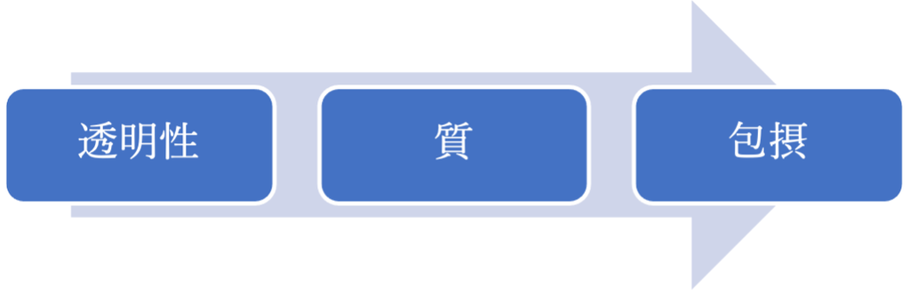

図1. OSを実装するうえで核となる価値：現在の方向性

ここには特定の方向性、つまりオープン性を追求する最善の道筋として、ある特有の価値観を優先させるような動きがあり、それがOSを実装する主な取り組みの大半を支えているといってよい（図1を参照）。第一に*透明性*を達成する必要がある[^3]。この点はOSにとってもっとも緊急かつ差し迫った課題として提示されることが多い。要するにすべてをオンライン上にあげ、さまざまな潜在ユーザがアクセスできるようにすることだ。第二に共有されるものの*質*が心配される。ウェブ上で流通する成果物や手法の信頼性を評価するための規準や仕組みを導入し、そのようなルールを守らないものには制裁を科すことが理想である。再現性という観念はまさにそのような規準のひとつとして大きな注目を集めており、領域横断的に適用することで、オンライン上で共有されるものの厳密性および信頼性を高めることが期待されている（National Academies 2019）。第三に包摂がある。これは適切な関心や専門知をもつ誰もが研究に関与し参加できる機会、つまり共有された諸資源を活用し精査に役立てることができる機会をもつことを意図している。ほとんどのOS政策文書において研究の透明性と質（しばしば再現可能性という形で示される）を向上させることの究極の目的および最終成果は包摂的かつ公正な研究プロセスというもので、それはつまり科学への参画が促されること、知識にとってよい貢献なのかよくない貢献なのかを区別しやすくさせることである（たとえば次。European Commission 2016, 2018; National Academies 2018; Burgelman et al. 2019; United Nations 2019）。

マートンやポパーを支持する人たちが重視した、再帰的、批判的、制度的に媒介された形で諸個人間が対立しあうことは、このように解釈されるOSから消えてしまっているわけではないものの、このOSは透明性という考えに基礎が置かれている。広く可視化されアクセス可能な研究要素のみが今後の研究にとって（多かれ少なかれ）信頼できる構成要素として適切に評価されることになる。この見方においては、諸々の資源と成果物を共有することから科学の正当性、科学への参画、科学に対する信頼、さらには経済成長といった望ましい結果が生じるのだ。しかし次章で見ていくように、この共有にもとづく「透明性ファースト」説では、OSがどのように実装され、どのような結果をもたらすかということを考えると、そううまくはいかない。

[^1]: 特許も望ましい成果物として高いステータスを与えられるかもしれないが、インパクトファクターに焦点が当てられた定量的指標にそれらを組み込むのも容易ではない。
[^2]: このモジュール化されたオブジェクト指向の科学認識論の問題点については第5章で論じる。
[^3]: 科学における透明性のさまざまな意味を分析したものとしてはElliott (2020)を参照のこと。